# Analysis of SARS-CoV-2 Sequencing Data from Experimentally Infected Hamsters and Ferrets

Sara Tagol

12 December, 2024

# Background and Overview

This is a report on SARS-CoV-2, including some variant analysis (Koyama *et al.*, 2020).The primary goals of this analysis were to assess the genomic features and single nucleotide polymorphism (SNP) distribution within the SARS-CoV-2 genome using a combination of biostatistical tools. By using bash script for sequence processing and R for data analysis and visualization, this study aimed to identify patterns in SNP distribution and frequency, as well as their association with gene lengths across the viral genome in two non-model organisms.

Using raw sequencing data which was then processed using bash tools such as bwa for sequence aligned and bcftools for variant calling. The file generated variant call format (VCF) files contain the SNP data. Next, to parse the VCF files, custom bash scripts were used to ensure the data was clean and ready for analysis. Using R, the cleaned data was imported and analysed to investigate the SNP distributions by sample and genomic location. These analyses included summarizing SNP counts, visualizing SNP distributions by gene, and looking at the relationship between gene length and SNP count. Figures including histograms, scatter plots and summary tables were made using the data to support these observations.

The use of hamsters and ferrets in research offers distinct advantages. Hamsters are known for their suitability as models for studying respiratory viruses due to their similarity to humans in terms of airway structure and immune response. Ferrets are considered gold-standard models for influenza and other respiratory infections because of their susceptibility to human respiratory viruses and their similarities in disease progression. Using these non-model organisms provides a good framework for studying viral behavior, host-pathogen interactions, and therapeutics.

The primary findings revealed that SNP counts varied a lot across genes, with the longer genes like ORF1ab and S having the highest SNP counts. This leads to possible correlations between gene length and SNP count. These observations are in line with the incredible genomic variation within SARS-CoV-2 and allow us to question why these specific genes might be so easily mutated.

This project combined sequence processing pipelines with statistical analysis to create an overview of SNP dynamics in the SARS-CoV-2 genome in non-model organisms.

# Methods

### Data Acquisition and Preprocessing

To investigate the genomic features of SARS-CoV-2, raw sequencing data was acquired from the following publicly available dataset: “SARS-CoV-2 Sequencing from experimentally infected hamsters and ferrets”(PRJNA894555), including VCF files for variant analysis. The metadata and sequence files were retrieved from the NCBI Sequence Read Archive (SRA) using the fasterq-dump (Biotechnology Information, 2024) command in the SRA toolkit. The downloaded sequence reads were quality-checked using FastQC (Andrews, 2010) and trimmed for adapter sequences using Trimmomatic (Bolger *et al.*, 2014).

### Sequence Alignment and Variant Calling

The trimmed reads were aligned to the SARS-CoV-2 reference genome (GenBank ID: NC_045512.2) using bwa mem (Li and Durbin, 2010). The resulting SAM files were converted to BAM format, sorted, and indexed using samtools (Li *et al.*, 2009). Variant calling was performed with bcftools mpileup and bcftools call to generate VCF files containing SNP information. Default parameters were used unless otherwise noted. Stringent filtering criteria were applied to ensure the reliability of the identified variants.

### Annotation and Data Cleaning

The VCF files were parsed and annotated using custom bash scripts and vcfR in R (Knaus and Grünwald, 2017). Additional annotations, such as gene names, positions, and functional consequences, were added using the SARS-CoV-2 genome annotation file in GFF format. The annotated data were saved in tabular format for downstream analyses.

### Pipeline Validation

All bash scripts used in the preprocessing and alignment steps were rigorously tested using shellcheck to ensure robustness and accuracy. All R scripts and RMarkdown files were run through lintr to verify they were following best coding practices. The RMarkdown report successfully knitted into HTML format, providing a comprehensive overview of the analyses performed (Xie *et al.*, 2021).

### Reproducibility

The project repository contains all scripts used in this analysis, with detailed comments explaining each step. Each script is appropriately named and organized within directories to facilitate reproducibility. Instructions for running the pipeline are provided in the README file included in the repository.

# Results and Discussion

### Results

The sequencing data analysis started with raw sequence files downloaded using the SRA toolkit. FastQC was used to ensure quality, and while most sequences met the required quality standards, there were a few exceptions where trimming was necessary to improve the data. Trimmomatic was applied, which addressed low-quality bases and adapter contamination effectively. Post-trimming, the sequences were rechecked, and overall quality scores improved significantly, suggesting the data was ready for downstream analysis. Variant analysis using the VCF files revealed distinct patterns of SNP distribution across the genome of SARS-CoV-2. Hamsters and ferrets demonstrated differences in SNP counts, particularly within the ORF1ab and spike (S) genes. These genes showed the highest SNP frequencies, aligning with findings in previous studies that identified these regions as hotspots for mutations in SARS-CoV-2 (Hoffmann *et al.*, 2020). To explore these variations further, a custom R script was used to correlate SNP counts with gene length. Unsurprisingly, larger genes, like ORF1ab, harbored more SNPs. This made sense biologically since a larger target area naturally allows for a higher chance of mutations. The smaller accessory genes showed fewer SNPs, as anticipated. The use of ggplot2 (Wickham, 2016)provided clear and interpretable visualizations that supported these observations.

### Discussion

The results align with the broader understanding of SARS-CoV-2’s mutation landscape. The high number of SNPs in ORF1ab and S genes underscores their role in viral fitness and adaptability, which has been highlighted in the literature. ORF1ab, being a large polyprotein, is vital for replication, while the S gene is key to receptor binding and entry into host cells (Hoffmann *et al.*, 2020). Ferrets and hamsters were useful models for this analysis because of their differential responses to SARS-CoV-2. While hamsters show robust viral replication, ferrets often serve as models for upper respiratory infections. The observed SNP patterns may also hint at host-specific pressures influencing viral evolution. While the findings are promising, it’s essential to acknowledge the study’s limitations. For instance, the dataset size was relatively small, and additional sequencing data from other host species could provide a more comprehensive understanding. Additionally, functional studies would be necessary to determine if these SNPs have any phenotypic effects. Overall, this study demonstrated the power of combining bioinformatics tools and visualization techniques to investigate viral genomics. It reinforced the importance of ORF1ab and S genes in the evolutionary dynamics of SARS-CoV-2, providing a foundation for future studies.

# Figures

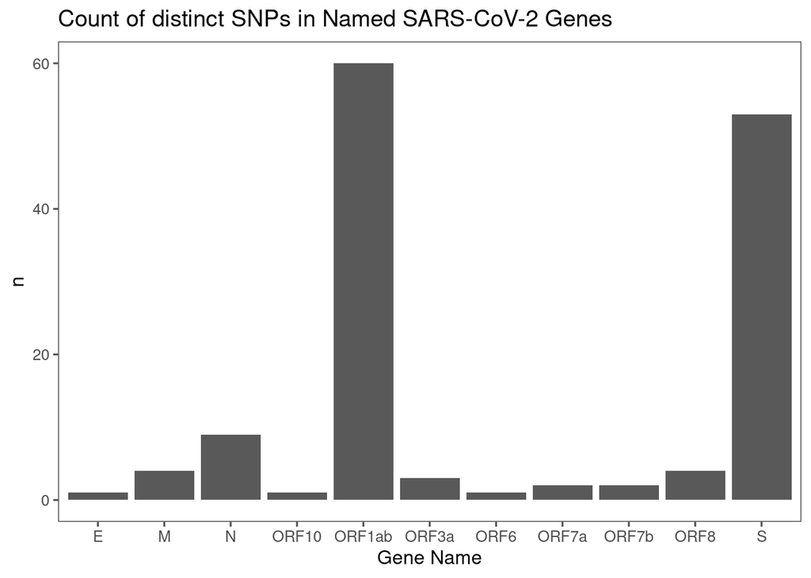

Figure 1: ORF1ab and S genes have more unique SNPs in the set of samples analyzed.

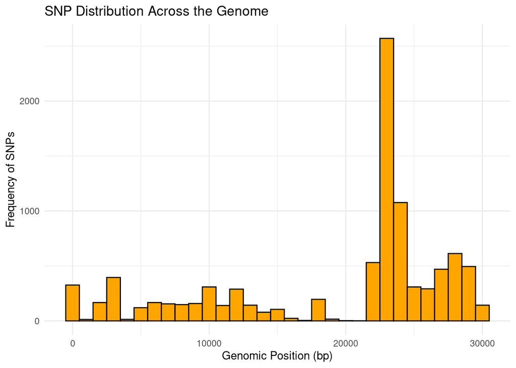

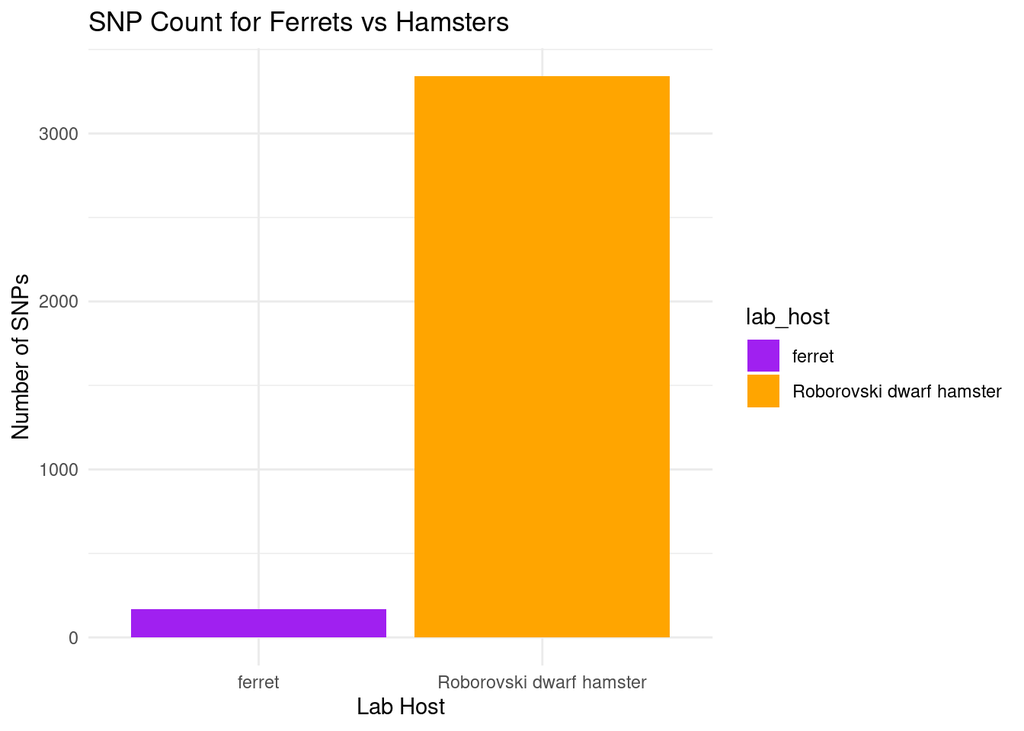

Figure 3: Roborovski dwarf /hamster has more SNPs than ferret.

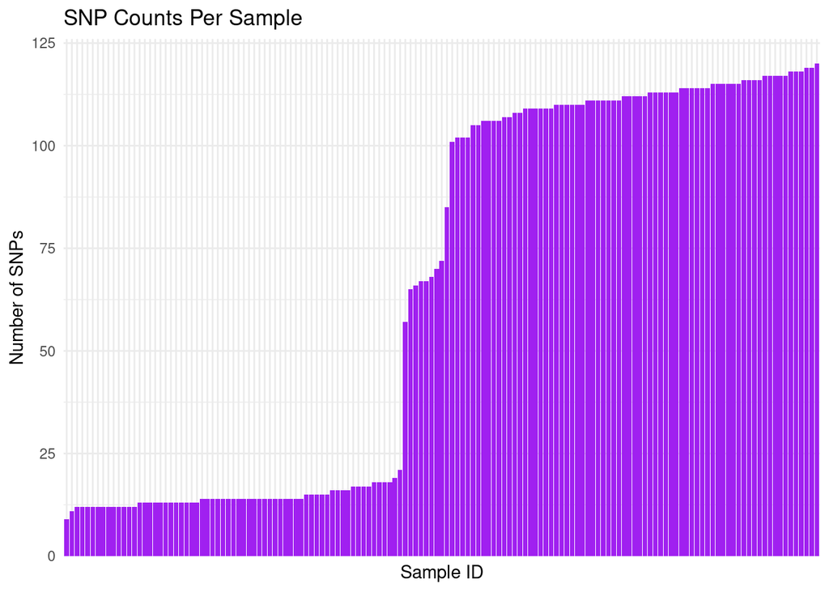

Figure 4: There is a variety in number of SNPs per sample.

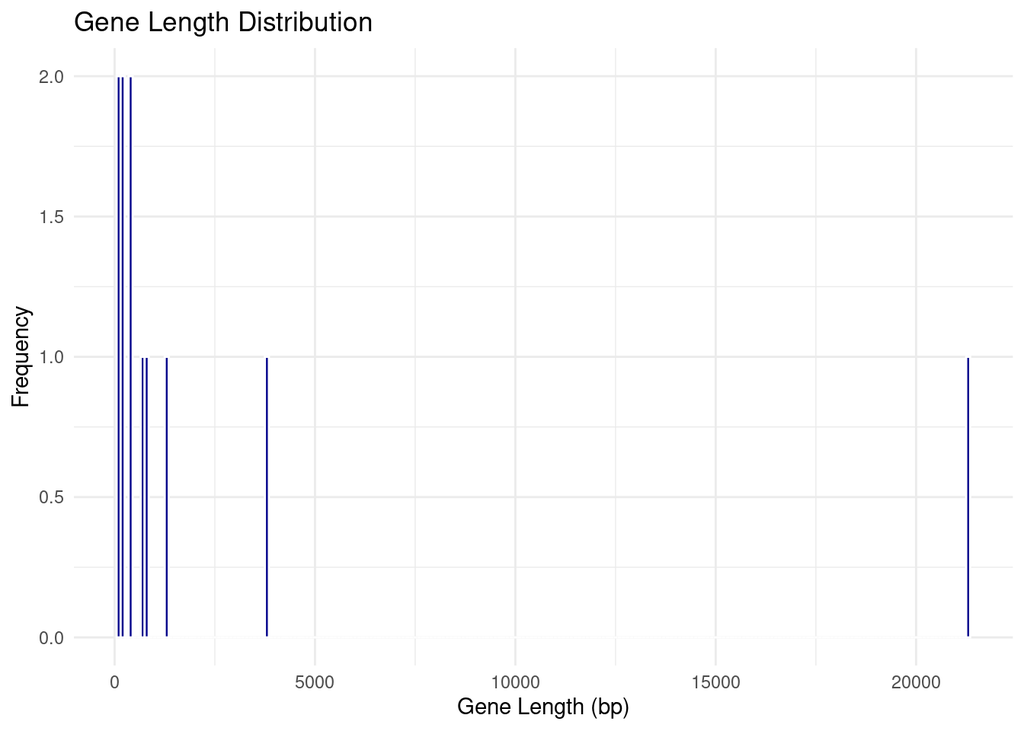

Figure 5: ORF1ab and S genes are much larger in length than the other genes.

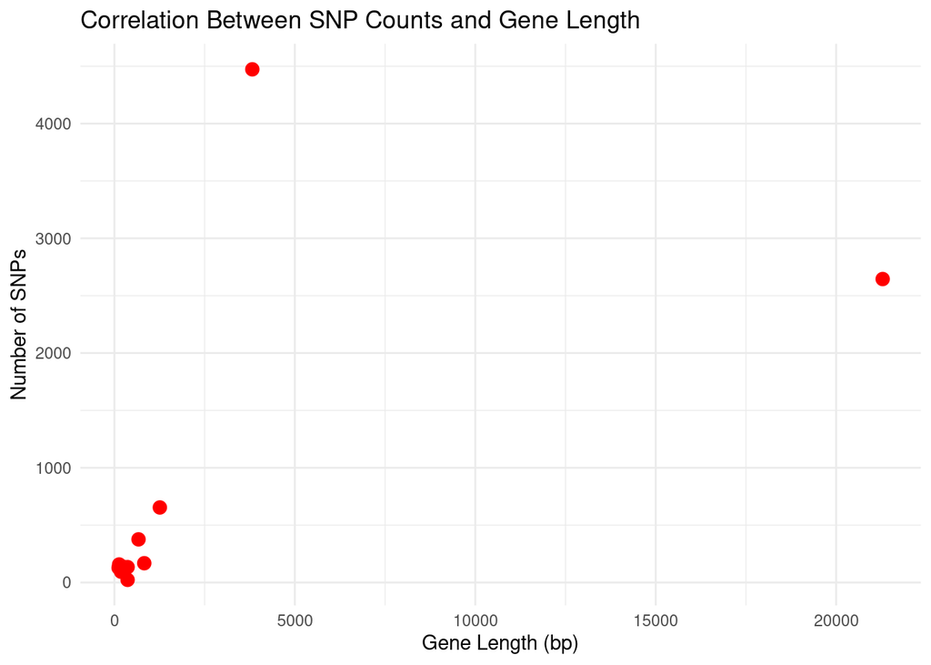

# Tables

| Gene Name | Start | End | Length (bp) |
| --- | --- | --- | --- |
| ORF1ab | 266 | 21555 | 21289 |
| S | 21563 | 25384 | 3821 |
| ORF3a | 25393 | 26220 | 827 |
| E | 26245 | 26472 | 227 |
| M | 26523 | 27191 | 668 |
| ORF6 | 27202 | 27387 | 185 |
| ORF7a | 27394 | 27759 | 365 |
| ORF7b | 27756 | 27887 | 131 |
| ORF8 | 27894 | 28259 | 365 |
| N | 28274 | 29533 | 1259 |
| ORF10 | 29558 | 29674 | 116 |

**Table 1**: Gene names, locations, and lengths in the SARS-CoV-2 genome.

| Gene Name | SNP Count |
| --- | --- |
| S | 4473 |
| ORF1ab | 2645 |
| N | 654 |
| M | 376 |
| ORF3a | 168 |

**Table 2**: Gene names and SNP counts. Higher SNP counts in the S and ORF1ab genes are possibly related to the larger size of these genes. # Sources Cited

Andrews,S. (2010) FastQC: A quality control tool for high throughput sequence data.

Biotechnology Information,N.C. for (2024) SRA toolkit documentation.

Bolger,A.M. *et al.* (2014) Trimmomatic: A flexible trimmer for illumina sequence data. *Bioinformatics*, **30**, 2114–2120.

Hoffmann,M. *et al.* (2020) SARS-cov-2 cell entry depends on ace2 and tmprss2 and is blocked by a clinically proven protease inhibitor. *Cell*, **181**, 271–280.

Koyama,T. *et al.* (2020) Variant analysis of sars-cov-2 genomes. *Bulletin of the World Health Organization*, **98**, 495.

Li,H. and Durbin,R. (2010) Fast and accurate short read alignment with Burrows–Wheeler transform. *Bioinformatics*, **26**, 589–595.

Li,H. *et al.* (2009) SAMtools: Sequence alignment/map format.

Wickham,H. (2016) Ggplot2: Elegant graphics for data analysis. *Springer*.

Xie,Y. *et al.* (2021) R markdown: The definitive guide CRC Press.